# Lab 7

Zeren Li

## Roadmap

- Goodness of Fit

## MLB

```r
data("mlb1", package="wooldridge")  #from wooldridge package

# variable definition
?mlb1

mlb <- mlb1 %>%
  # add population variable
  mutate(total_pop=(100*whitepop)/ percwhte )
```

1. Set a random number seed at any positive integer to start the randomization process. This will allow me to repeat the process and always obtain the same numbers

```r
set.seed(2019)
n = nrow(mlb)

n.train = floor(.75*n) # 75% training set, 25% test set
train = sample(1:n, size=n.train, rep=F)

mlb_train <- mlb[train,]
mlb_test <- mlb[-train,]
```

### Measuring Quality of Fit

- Measure of Quality of fit

$$MSE = \frac 1 n \sum_i{(Y_i - \hat y)^2}$$

- OLS: training MSE can be driven smaller by adding more predictors
- How well does model predict for new data $y^*$?

$$MSE = \frac 1 {n^*} \sum_i{(y^*_i - \widehat{f(x^*_i)})^2}$$

- No guarantee that model that has lowest training MSE will be the best out of sample MSE

## Bias - Variance Trade Off

- MSE for Prediction
  $$\E[(y^*- \widehat{f(x^*)})^2] = \Var(\widehat{f(x^*)}) + [\Bias(\widehat{f(x^*)}) ]^2 + \Var(\epsilon^*)$$
- Variance: amount $\hat y$ varies if we use a different training set
- Bias: error that is introduced by approximating model by a potentially simpler model
- Variance of error: irreducible error (Normal models)
- Want a statistical procedure that has low variance and low bias
- Need a test set

## Evaluation on Test Set

- Split the data into 2 groups: training and test
- Fit model to training data
- Predict on test data
- Evaluate MSE (or root MSE) on test data

### Exploratory data analysis

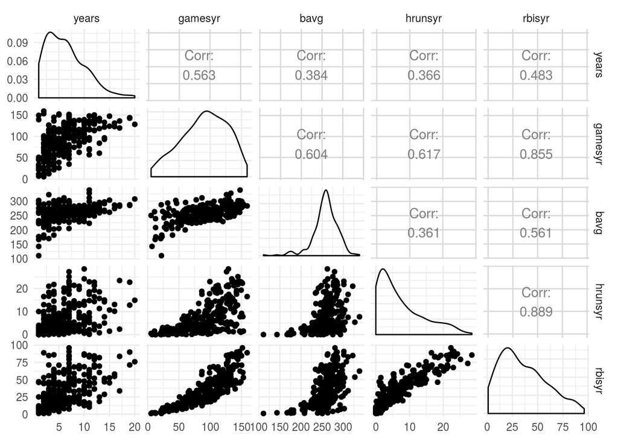

```r
mlb_train %>%
    select("years", "gamesyr", "bavg", "hrunsyr", "rbisyr")   %>%
ggpairs()
```

### summary statistics

```r
mlb_train %>%
    select("years", "gamesyr", "bavg", "hrunsyr", "rbisyr")   %>%
    stargazer(., header = F)
```

[output not shown]

## Fit a model

- The basline model of player salary. This is where we will begin my analysis. Most experts agree that these variables are important.
- Then, we add my key theoretical causal variables. Batting Average, Home Runs, and RBIs, all in the most recent year. See Page 151 Wooldridge for this analysis.

```r
# compute rmse
rmse_bh <- function(y, ypred) {
          rmse = sqrt(mean((y - ypred)^2))
          return(rmse)
          }


m1 <- lm(lsalary ~ years + gamesyr, mlb_train )
yhat <- predict(m1)
rmse_bh(mlb_train$lsalary, yhat)
```

```
## [1] 0.7445994
```

```r
summary(m1)
```

```
##
## Call:
## lm(formula = lsalary ~ years + gamesyr, data = mlb_train)
##
## Residuals:
##     Min      1Q  Median      3Q     Max
## -2.1966 -0.4532 -0.0453  0.4748  2.7023
##
## Coefficients:
##              Estimate Std. Error t value Pr(>|t|)
## (Intercept) 11.192992   0.125663   89.07  < 2e-16 ***
## years        0.084890   0.014388    5.90 1.12e-08 ***
## gamesyr      0.019714   0.001548   12.73  < 2e-16 ***
## ---
## Signif. codes:  0 '***' 0.001 '**' 0.01 '*' 0.05 '.' 0.1 ' ' 1
##
## Residual standard error: 0.7489 on 261 degrees of freedom
## Multiple R-squared:  0.6122, Adjusted R-squared:  0.6092
## F-statistic:   206 on 2 and 261 DF,  p-value: < 2.2e-16
```

```r
m2 <- lm(lsalary ~ years + gamesyr + bavg + hrunsyr + rbisyr , mlb_train )
summary(m2)
```

```
##
## Call:
## lm(formula = lsalary ~ years + gamesyr + bavg + hrunsyr + rbisyr,
##     data = mlb_train)
##
## Residuals:
##      Min       1Q   Median       3Q      Max
## -2.25897 -0.47736 -0.05463  0.47067  2.77040
##
## Coefficients:
##              Estimate Std. Error t value Pr(>|t|)
## (Intercept) 10.750380   0.464087  23.165  < 2e-16 ***
## years        0.082111   0.013943   5.889 1.21e-08 ***
## gamesyr      0.012490   0.003127   3.994 8.47e-05 ***
## bavg         0.002849   0.002005   1.421    0.157
## hrunsyr      0.026667   0.018740   1.423    0.156
## rbisyr       0.005404   0.008349   0.647    0.518
## ---
## Signif. codes:  0 '***' 0.001 '**' 0.01 '*' 0.05 '.' 0.1 ' ' 1
##
## Residual standard error: 0.7221 on 258 degrees of freedom
## Multiple R-squared:  0.6436, Adjusted R-squared:  0.6367
## F-statistic: 93.18 on 5 and 258 DF,  p-value: < 2.2e-16
```

### Standard Error of Residual

common summary statistics are $SER$, $R^2$ and the adjusted $R^2$.

$$SER = s_{\hat u} = \sqrt{s_{\hat u}^2}$$
where
$$s_{\hat u}^2 = \frac{1}{n-k-1} \, SSR$$

with $k$ denoting the number of regressors *excluding* the intercept.

### Adjusted R^2

- $R^2$ increasing whenever an additional regressor is added to the model
  - Adding a regressor —> $SSR$ goes down —> $R^2$ goes up
- Adjusted $R^2$ “punishes” the addition of regressors using a correction factor, which is defined as

$$\bar{R}^2 = 1-\frac{n-1}{n-k-1} \, \frac{SSR}{TSS}.$$

# Compute Adjusted R^2 by hand

```r
# define the components
n <- nrow(mlb_train)                            # number of observations (rows)
k <- length(m2$coefficients)-1                  # number of regressors
y_mean <- mean(mlb_train$lsalary)

SSR <- sum(residuals(m2)^2)               # sum of squared residuals
TSS <- sum((mlb_train$lsalary -  y_mean)^2)       # total sum of squares
ESS <- sum((fitted(m2) - y_mean)^2)       # explained sum of squares

# compute the measures

SER <- sqrt(1/(n-k-1) * SSR)                    # standard error of the regression
Rsq <- 1 - (SSR / TSS)                          # R^2
adj_Rsq <- 1 - (n-1)/(n-k-1) * SSR/TSS          # adj. R^2

# print the measures to the console
c("SER" = SER, "R2" = Rsq, "Adj.R2" = adj_Rsq)
```

```
##       SER        R2    Adj.R2
## 0.7220545 0.6435879 0.6366807
```

## Joint Hypothesis Testing Using the F-Statistic

- Can we reject the hypothesis that the coefficient are zero?
- A joint hypothesis imposes restrictions on multiple regression coefficients.
- This is different from conducting individual $t$-tests where a restriction is imposed on a single coefficient.

The homoskedasticity-only $F$-Statistic:

$$F = \frac{(SSR_{\text{restricted}} - SSR_{\text{unrestricted}})/q}{SSR_{\text{unrestricted}} / (n-k-1)}$$

- $SSR_{restricted}$ being the sum of squared residuals from the restricted regression, i.e., the regression where we impose the restriction.
- $SSR_{unrestricted}$ is the sum of squared residuals from the full model
- $q$ is the number of restrictions under the null
- $k$ is the number of regressors in the unrestricted regression

```r
linearHypothesis(m2, c("bavg=0", "hrunsyr=0", "rbisyr=0"))
```

|  | Res.Df | RSS | Df | Sum of Sq | F | Pr(>F) |
| --- | --- | --- | --- | --- | --- | --- |
| 1 | 261 | 146.3691 | NA | NA | NA | NA |
| 2 | 258 | 134.5116 | 3 | 11.8575 | 7.581095 | 7.0495e-05 |

```r
# compute by hand
SSR_r <- sum(residuals(m1)^2)
SSR_ur <- sum(residuals(m2)^2)
q <- 3      # number of restriction
n <- nrow(mlb_train)            # number of observations (rows)
k <- length(m2$coefficients)-1  # number of regressors
(F_stats <- ((SSR_r - SSR_ur) / q)/(SSR_ur / (n - k - 1)))
```

```
## [1] 7.581095
```

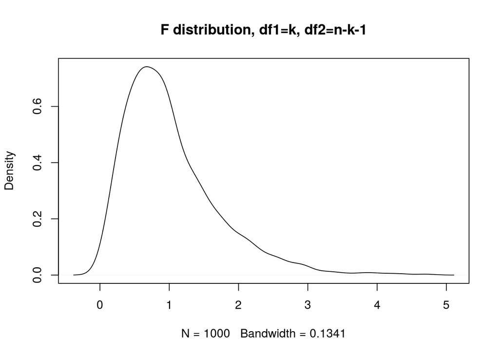

```r
plot(density(rf(1000, df1 = k , df2 = n - k - 1, )),
     main = "F distribution, df1=k, df2=n-k-1") ; abline(v = F_stats, col = 'red')
```

Why are the baseball stats insignificant in indiviual t-testing, even though they are jointly significant?

Our gut reaction should be that they are highly collinear. Those who hit more home runs are more likely to have more runs batted in

Indeed, they are. Look at the VIF on RBIs. It is almost entirely explained by the other variables.

Indeed, home runs and rbis are have a .89 correlation.

```r
vif(m2)
```

```
##     years   gamesyr      bavg   hrunsyr    rbisyr
##  1.478286  6.422273  1.706120  8.013202 18.605876
```

```r
cor(mlb_train$hrunsyr, mlb_train$rbisyr)
```

```
## [1] 0.8890802
```

Theoretically, We choose to drop rbis, because rbis are a function of other players, whereas homeruns are only created by a single player. What happens to the coefficient and standard errors on home runs after I do this?

```r
m3 <- lm(lsalary ~ years + gamesyr + bavg + hrunsyr, mlb_train)
summary(m3)
```

```
##
## Call:
## lm(formula = lsalary ~ years + gamesyr + bavg + hrunsyr, data = mlb_train)
##
## Residuals:
##      Min       1Q   Median       3Q      Max
## -2.21188 -0.47934 -0.06134  0.47679  2.79213
##
## Coefficients:
##              Estimate Std. Error t value Pr(>|t|)
## (Intercept) 10.636490   0.428947  24.797  < 2e-16 ***
## years        0.081499   0.013896   5.865 1.36e-08 ***
## gamesyr      0.014056   0.001979   7.103 1.18e-11 ***
## bavg         0.003198   0.001929   1.658   0.0985 .
## hrunsyr      0.037505   0.008404   4.462 1.21e-05 ***
## ---
## Signif. codes:  0 '***' 0.001 '**' 0.01 '*' 0.05 '.' 0.1 ' ' 1
##
## Residual standard error: 0.7212 on 259 degrees of freedom
## Multiple R-squared:  0.643,  Adjusted R-squared:  0.6375
## F-statistic: 116.6 on 4 and 259 DF,  p-value: < 2.2e-16
```

How about adding some other measures of baseball successs

```r
m4 <- lm(lsalary ~ years + gamesyr + bavg + hrunsyr + runsyr + fldperc + sbasesyr, mlb_train)
summary(m4)
```

```
##
## Call:
## lm(formula = lsalary ~ years + gamesyr + bavg + hrunsyr + runsyr +
##     fldperc + sbasesyr, data = mlb_train)
##
## Residuals:
##      Min       1Q   Median       3Q      Max
## -2.05884 -0.48032 -0.02019  0.48834  2.62632
##
## Coefficients:
##              Estimate Std. Error t value Pr(>|t|)
## (Intercept)  6.431809   2.608766   2.465 0.014340 *
## years        0.081607   0.013890   5.875 1.31e-08 ***
## gamesyr      0.011404   0.003161   3.607 0.000372 ***
## bavg         0.002641   0.002025   1.304 0.193278
## hrunsyr      0.033957   0.010457   3.247 0.001321 **
## runsyr       0.005375   0.006113   0.879 0.380079
## fldperc      0.004514   0.002655   1.700 0.090345 .
## sbasesyr    -0.001539   0.005851  -0.263 0.792706
## ---
## Signif. codes:  0 '***' 0.001 '**' 0.01 '*' 0.05 '.' 0.1 ' ' 1
##
## Residual standard error: 0.7205 on 256 degrees of freedom
## Multiple R-squared:  0.6479, Adjusted R-squared:  0.6382
## F-statistic: 67.28 on 7 and 256 DF,  p-value: < 2.2e-16
```

```r
cor(mlb_train$sbasesyr, mlb_train$runsyr)
```

```
## [1] 0.6192868
```

```r
vif(m4)
```

```
##     years   gamesyr      bavg   hrunsyr    runsyr   fldperc  sbasesyr
##  1.473326  6.592439  1.747223  2.505770 11.215820  1.026456  2.398010
```

Are fielding percentages and stolen bases doing anything for us? Let’s do an F-test of the joint significance of these variables.

```r
m5 <- lm(lsalary ~ years + gamesyr + bavg + hrunsyr + runsyr + fldperc + sbasesyr , mlb_train)
summary(m5)
```

```
##
## Call:
## lm(formula = lsalary ~ years + gamesyr + bavg + hrunsyr + runsyr +
##     fldperc + sbasesyr, data = mlb_train)
##
## Residuals:
##      Min       1Q   Median       3Q      Max
## -2.05884 -0.48032 -0.02019  0.48834  2.62632
##
## Coefficients:
##              Estimate Std. Error t value Pr(>|t|)
## (Intercept)  6.431809   2.608766   2.465 0.014340 *
## years        0.081607   0.013890   5.875 1.31e-08 ***
## gamesyr      0.011404   0.003161   3.607 0.000372 ***
## bavg         0.002641   0.002025   1.304 0.193278
## hrunsyr      0.033957   0.010457   3.247 0.001321 **
## runsyr       0.005375   0.006113   0.879 0.380079
## fldperc      0.004514   0.002655   1.700 0.090345 .
## sbasesyr    -0.001539   0.005851  -0.263 0.792706
## ---
## Signif. codes:  0 '***' 0.001 '**' 0.01 '*' 0.05 '.' 0.1 ' ' 1
##
## Residual standard error: 0.7205 on 256 degrees of freedom
## Multiple R-squared:  0.6479, Adjusted R-squared:  0.6382
## F-statistic: 67.28 on 7 and 256 DF,  p-value: < 2.2e-16
```

```r
linearHypothesis(m5, c("fldperc=0","sbasesyr=0"))
```

|  | Res.Df | RSS | Df | Sum of Sq | F | Pr(>F) |
| --- | --- | --- | --- | --- | --- | --- |
| 1 | 258 | 134.4219 | NA | NA | NA | NA |
| 2 | 256 | 132.8990 | 2 | 1.522833 | 1.466697 | 0.2326179 |

We cannot reject the null hypothesis at the .05 level,

The sign flip on sbases is probably due to high collinearity with runs (lead-off hitters tend to have high runs and stolen bases) and fielding percentage is individually insignificant. I choose to drop them both from the model

I haven’t yet controlled for the race of the player or the market size, might these have an impact?

Clearly, these other factors are important, what sort of bias might they be causing in my regressions. Think this through carefully.

First, I need to create a total measure of population, which I unfortunately don’t have. How would I calculate one?

```r
m6 <- lm(lsalary ~ years + bavg + hrunsyr + runsyr + total_pop + pcinc + hispan + black, mlb_train)
summary(m6)
```

```
##
## Call:
## lm(formula = lsalary ~ years + bavg + hrunsyr + runsyr + total_pop +
##     pcinc + hispan + black, data = mlb_train)
##
## Residuals:
##     Min      1Q  Median      3Q     Max
## -2.0672 -0.5159 -0.1017  0.5610  2.5023
##
## Coefficients:
##               Estimate Std. Error t value Pr(>|t|)
## (Intercept)  1.106e+01  5.874e-01  18.832  < 2e-16 ***
## years        9.548e-02  1.453e-02   6.571 3.11e-10 ***
## bavg         4.300e-03  2.232e-03   1.927   0.0552 .
## hrunsyr      3.736e-02  9.414e-03   3.969 9.56e-05 ***
## runsyr       1.705e-02  3.369e-03   5.062 8.29e-07 ***
## total_pop   -2.480e-09  8.961e-09  -0.277   0.7822
## pcinc       -9.052e-06  1.857e-05  -0.487   0.6264
## hispan       4.404e-02  1.334e-01   0.330   0.7416
## black       -8.592e-02  1.100e-01  -0.781   0.4357
## ---
## Signif. codes:  0 '***' 0.001 '**' 0.01 '*' 0.05 '.' 0.1 ' ' 1
##
## Residual standard error: 0.7506 on 239 degrees of freedom
##   (16 observations deleted due to missingness)
## Multiple R-squared:  0.6082, Adjusted R-squared:  0.5951
## F-statistic: 46.37 on 8 and 239 DF,  p-value: < 2.2e-16
```

```r
linearHypothesis(m6, c("total_pop=0","pcinc=0","hispan=0","black=0"))
```

|  | Res.Df | RSS | Df | Sum of Sq | F | Pr(>F) |
| --- | --- | --- | --- | --- | --- | --- |
| 1 | 243 | 135.3900 | NA | NA | NA | NA |
| 2 | 239 | 134.6451 | 4 | 0.7449036 | 0.3305578 | 0.8572752 |

No, they are jointly insignificant. Demographic factors do not seem to have an effect on salary.

How about a position. Short-stop is a highly skilled position. What if we tested whether short-stops are more highly paid than other positions?

```r
m7 <- lm(lsalary ~ years + gamesyr + bavg + hrunsyr + runsyr + shrtstop, mlb_train)
summary(m7)
```

```
##
## Call:
## lm(formula = lsalary ~ years + gamesyr + bavg + hrunsyr + runsyr +
##     shrtstop, data = mlb_train)
##
## Residuals:
##     Min      1Q  Median      3Q     Max
## -2.1897 -0.4673 -0.0589  0.4897  2.7449
##
## Coefficients:
##              Estimate Std. Error t value Pr(>|t|)
## (Intercept) 10.801320   0.473422  22.815  < 2e-16 ***
## years        0.081719   0.013959   5.854 1.46e-08 ***
## gamesyr      0.012316   0.003093   3.982 8.91e-05 ***
## bavg         0.002701   0.002024   1.335 0.183135
## hrunsyr      0.034768   0.009083   3.828 0.000162 ***
## runsyr       0.003681   0.004792   0.768 0.443054
## shrtstop    -0.043047   0.133243  -0.323 0.746906
## ---
## Signif. codes:  0 '***' 0.001 '**' 0.01 '*' 0.05 '.' 0.1 ' ' 1
##
## Residual standard error: 0.7231 on 257 degrees of freedom
## Multiple R-squared:  0.644,  Adjusted R-squared:  0.6357
## F-statistic: 77.47 on 6 and 257 DF,  p-value: < 2.2e-16
```

```r
linearHypothesis(m7, c("shrtstop=0"))
```

|  | Res.Df | RSS | Df | Sum of Sq | F | Pr(>F) |
| --- | --- | --- | --- | --- | --- | --- |
| 1 | 258 | 134.4219 | NA | NA | NA | NA |
| 2 | 257 | 134.3673 | 1 | 0.05456933 | 0.104373 | 0.7469064 |

```r
# And catcher?
m8 <- lm(lsalary ~ years + gamesyr + bavg + hrunsyr + runsyr + catcher, mlb_train)

rmse_bh(m8$model$lsalary, predict(m8))
```

```
## [1] 0.7016798
```

```r
summary(m8)
```

```
##
## Call:
## lm(formula = lsalary ~ years + gamesyr + bavg + hrunsyr + runsyr +
##     catcher, data = mlb_train)
##
## Residuals:
##      Min       1Q   Median       3Q      Max
## -2.10355 -0.46562 -0.02752  0.47326  2.85100
##
## Coefficients:
##              Estimate Std. Error t value Pr(>|t|)
## (Intercept) 10.795731   0.460299  23.454  < 2e-16 ***
## years        0.076478   0.013804   5.540 7.46e-08 ***
## gamesyr      0.011904   0.003036   3.921 0.000113 ***
## bavg         0.002188   0.001985   1.102 0.271492
## hrunsyr      0.033910   0.008718   3.890 0.000128 ***
## runsyr       0.007437   0.004881   1.524 0.128815
## catcher      0.396339   0.133763   2.963 0.003332 **
## ---
## Signif. codes:  0 '***' 0.001 '**' 0.01 '*' 0.05 '.' 0.1 ' ' 1
##
## Residual standard error: 0.7112 on 257 degrees of freedom
## Multiple R-squared:  0.6556, Adjusted R-squared:  0.6476
## F-statistic: 81.53 on 6 and 257 DF,  p-value: < 2.2e-16
```

```r
linearHypothesis(m8, c("catcher=0"))
```

|  | Res.Df | RSS | Df | Sum of Sq | F | Pr(>F) |
| --- | --- | --- | --- | --- | --- | --- |
| 1 | 258 | 134.4219 | NA | NA | NA | NA |
| 2 | 257 | 129.9816 | 1 | 4.440285 | 8.779345 | 0.00333225 |